# IS 6489: Module 5 | PacDev

Meag Tessmann

Oct 28 - Nov 3

## Load data and packages

```r
library(scales)
library(tidyverse)
d <- read_csv("LAHomes.csv")
glimpse(d)
```

```
## Observations: 1,594
## Variables: 9
## $ city   <chr> "Long Beach", "Long Beach", "Long Beach", "Long Beach", "…
## $ type   <chr> NA, NA, NA, NA, NA, NA, NA, NA, NA, NA, NA, NA, NA, NA, N…
## $ bed    <dbl> 0, 0, 0, 0, 0, 1, 1, 1, 1, 1, 1, 1, 1, 1, 1, 1, 1, 1, 1, …
## $ bath   <dbl> 1, 1, 1, 1, 1, 1, 1, 1, 1, 1, 1, 1, 1, 1, 1, 1, 1, 1, 1, …
## $ garage <chr> NA, NA, NA, "1", "1", NA, NA, NA, NA, NA, NA, NA, NA, "1"…
## $ sqft   <dbl> 513, 550, 550, 1030, 1526, 552, 558, 596, 744, 750, 750, …
## $ pool   <chr> NA, NA, NA, NA, NA, NA, NA, NA, NA, NA, NA, NA, NA, NA, N…
## $ spa    <lgl> NA, NA, NA, NA, NA, NA, NA, NA, NA, NA, NA, NA, NA, NA, N…
## $ price  <dbl> 119000, 153000, 205000, 300000, 375000, 159900, 135000, 1…
```

```r
summary(d)
```

```
##      city               type                bed              bath
##  Length:1594        Length:1594        Min.   : 0.000   Min.   : 1.000
##  Class :character   Class :character   1st Qu.: 2.000   1st Qu.: 1.000
##  Mode  :character   Mode  :character   Median : 3.000   Median : 2.000
##                                        Mean   : 2.755   Mean   : 2.444
##                                        3rd Qu.: 3.000   3rd Qu.: 3.000
##                                        Max.   :17.000   Max.   :30.000
##     garage               sqft           pool             spa
##  Length:1594        Min.   :  403   Length:1594        Mode:logical
##  Class :character   1st Qu.:  960   Class :character   NA's:1594
##  Mode  :character   Median : 1380   Mode  :character
##                     Mean   : 1963
##                     3rd Qu.: 2078
##                     Max.   :28000
##      price
##  Min.   :  100000
##  1st Qu.:  275000
##  Median :  488944
##  Mean   : 1254851
##  3rd Qu.:  988750
##  Max.   :89950000
```

Data dictionary: - city: name of city - type: type of dwelling, SFR or Condo/Twh - bed: number of bedrooms - bath: number of baths - garage: size of garage (number of cars) - sqft: size of dwelling - pool: indicator for pool - spa: indicator for spa - price: sales price

## Cleaning

1. `spa`.

```r
table(d$spa, useNA = "always")
```

```
##
## <NA>
## 1594
```

2. `pool`

```r
table(d$pool, useNA = "always")
```

```
##
##    Y <NA>
##  146 1448
```

3. `type`.

```r
table(d$type, useNA = "always")
```

```
##
## Condo/Twh       SFR      <NA>
##       639       916        39
```

4. `garage`.

```r
table(d$garage, useNA = "always")
```

```
##
##    1    2    3   4+ <NA>
##  260  666   37    6  625
```

```r
d <- d %>%
  dplyr::select(-spa) %>%
  mutate(pool = ifelse(is.na(pool), "N", "Y") %>% factor,
        garage = ifelse(is.na(garage), "0", garage) %>% factor,
        city = factor(city),
        type = factor(type))


glimpse(d)
```

```
## Observations: 1,594
## Variables: 8
## $ city   <fct> Long Beach, Long Beach, Long Beach, Long Beach, Long Beac…
## $ type   <fct> NA, NA, NA, NA, NA, NA, NA, NA, NA, NA, NA, NA, NA, NA, N…
## $ bed    <dbl> 0, 0, 0, 0, 0, 1, 1, 1, 1, 1, 1, 1, 1, 1, 1, 1, 1, 1, 1, …
## $ bath   <dbl> 1, 1, 1, 1, 1, 1, 1, 1, 1, 1, 1, 1, 1, 1, 1, 1, 1, 1, 1, …
## $ garage <fct> 0, 0, 0, 1, 1, 0, 0, 0, 0, 0, 0, 0, 0, 1, 1, 1, 1, 1, 2, …
## $ sqft   <dbl> 513, 550, 550, 1030, 1526, 552, 558, 596, 744, 750, 750, …
## $ pool   <fct> N, N, N, N, N, N, N, N, N, N, N, N, N, N, N, N, N, N, N, …
## $ price  <dbl> 119000, 153000, 205000, 300000, 375000, 159900, 135000, 1…
```

```r
summary(d)
```

```
##             city             type          bed              bath
##  Beverly Hills: 232   Condo/Twh:639   Min.   : 0.000   Min.   : 1.000
##  Long Beach   :1062   SFR      :916   1st Qu.: 2.000   1st Qu.: 1.000
##  Santa Monica : 204   NA's     : 39   Median : 3.000   Median : 2.000
##  Westwood     :  96                   Mean   : 2.755   Mean   : 2.444
##                                       3rd Qu.: 3.000   3rd Qu.: 3.000
##                                       Max.   :17.000   Max.   :30.000
##  garage        sqft       pool         price
##  0 :625   Min.   :  403   N:1448   Min.   :  100000
##  1 :260   1st Qu.:  960   Y: 146   1st Qu.:  275000
##  2 :666   Median : 1380            Median :  488944
##  3 : 37   Mean   : 1963            Mean   : 1254851
##  4+:  6   3rd Qu.: 2078            3rd Qu.:  988750
##           Max.   :28000            Max.   :89950000
```

## Q1

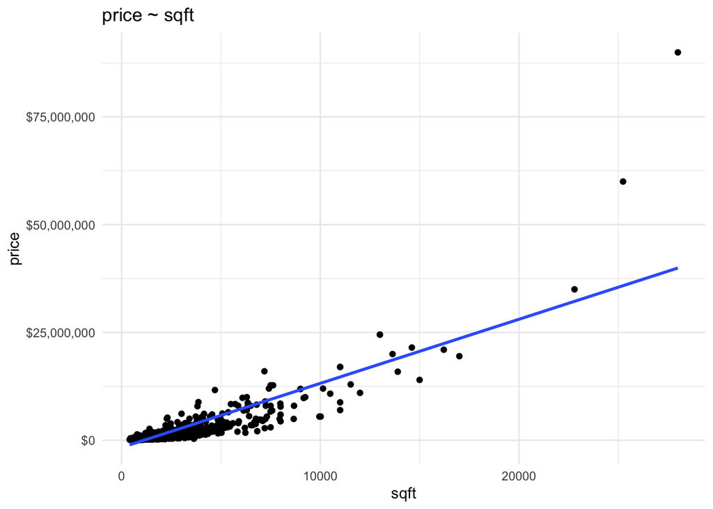

```r
ggplot(d, aes(sqft, price)) +
  geom_point() +
  theme_minimal() +
  stat_smooth(method="lm", se = F) +
  labs(title = "price ~ sqft") +
  scale_y_continuous(label=dollar)
```

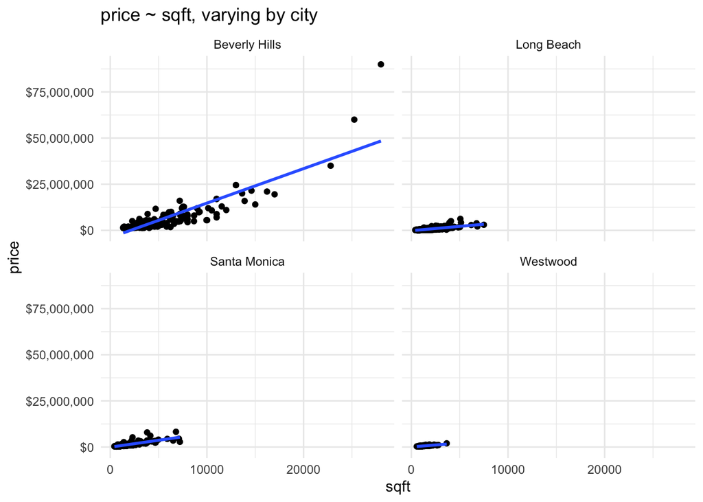

```r
ggplot(d, aes(sqft, price)) +
  geom_point() +
  theme_minimal() +
  facet_wrap(~city) +
  stat_smooth(method="lm", se = F) +
  labs(title = "price ~ sqft, varying by city") +
  scale_y_continuous(label=dollar)
```

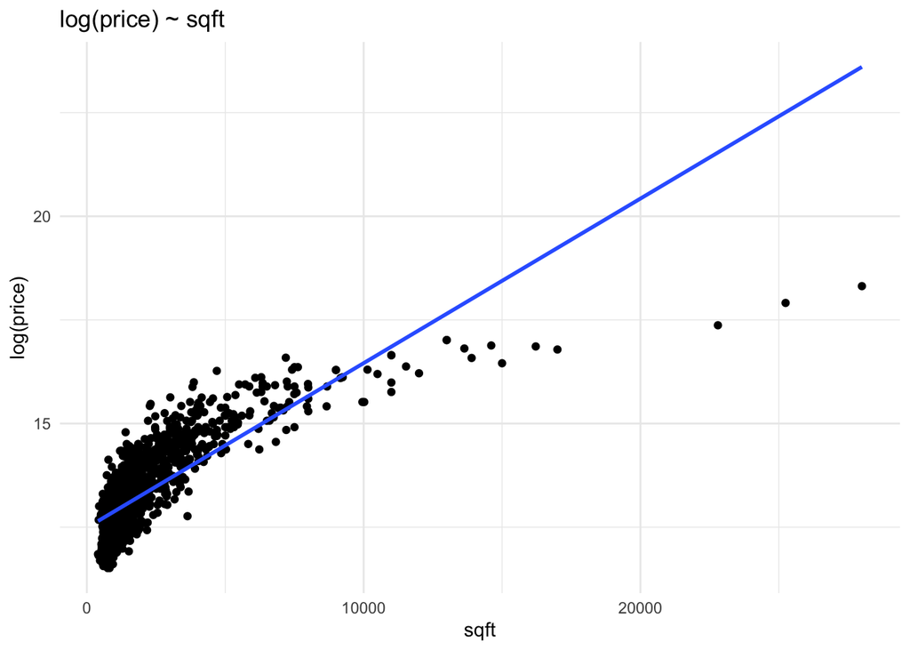

```r
ggplot(d, aes(sqft, log(price))) +
  geom_point() +
  theme_minimal() +
  stat_smooth(method="lm", se = F) +
  labs(title = "log(price) ~ sqft")
```

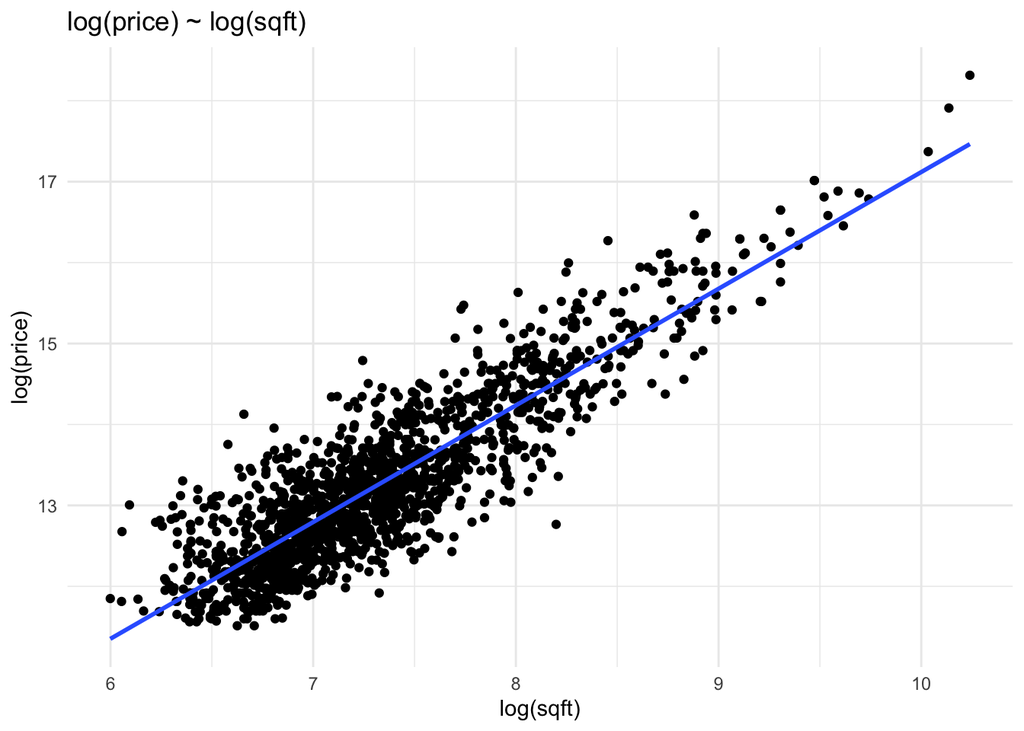

```r
ggplot(d, aes(log(sqft), log(price))) +
  geom_point() +
  theme_minimal() +
  stat_smooth(method="lm", se = F) +
  labs(title = "log(price) ~ log(sqft)")
```

> *Answer*  
> This log-log model appears to fit the data better than the previous plots. The data appears to be more linear, without a parabolic shape veering away from the regression line. The data appears to have a more even spread as well, though still exhibits skewing.

## Q2

```r
model_1 <- lm(log(price) ~ log(sqft), data=d)
summary(model_1)
```

```
##
## Call:
## lm(formula = log(price) ~ log(sqft), data = d)
##
## Residuals:
##      Min       1Q   Median       3Q      Max
## -1.75640 -0.35315 -0.04846  0.32215  1.82580
##
## Coefficients:
##             Estimate Std. Error t value Pr(>|t|)
## (Intercept)  2.70279    0.14369   18.81   <2e-16 ***
## log(sqft)    1.44158    0.01954   73.79   <2e-16 ***
## ---
## Signif. codes:  0 '***' 0.001 '**' 0.01 '*' 0.05 '.' 0.1 ' ' 1
##
## Residual standard error: 0.496 on 1592 degrees of freedom
## Multiple R-squared:  0.7738, Adjusted R-squared:  0.7736
## F-statistic:  5446 on 1 and 1592 DF,  p-value: < 2.2e-16
```

```r
model_1$coefficients[2]
```

```
## log(sqft)
##  1.441583
```

> *Answer*  
> Coefficient: 1.44158  
> Each 1% increase in the predictor, log square feet, is associated with a 1.442% increase in the outcome, log price.

## Q3

```r
model_2 <- lm(price ~ sqft, data=d)

model_3 <- lm(log(price) ~ log(sqft), data=d)

summary(model_2)
```

```
##
## Call:
## lm(formula = price ~ sqft, data = d)
##
## Residuals:
##      Min       1Q   Median       3Q      Max
## -7732777  -363898   246242   601763 50004033
##
## Coefficients:
##               Estimate Std. Error t value Pr(>|t|)
## (Intercept) -1.662e+06  6.446e+04  -25.78   <2e-16 ***
## sqft         1.486e+03  2.271e+01   65.44   <2e-16 ***
## ---
## Signif. codes:  0 '***' 0.001 '**' 0.01 '*' 0.05 '.' 0.1 ' ' 1
##
## Residual standard error: 1859000 on 1592 degrees of freedom
## Multiple R-squared:  0.729,  Adjusted R-squared:  0.7288
## F-statistic:  4282 on 1 and 1592 DF,  p-value: < 2.2e-16
```

```r
summary(model_3)
```

```
##
## Call:
## lm(formula = log(price) ~ log(sqft), data = d)
##
## Residuals:
##      Min       1Q   Median       3Q      Max
## -1.75640 -0.35315 -0.04846  0.32215  1.82580
##
## Coefficients:
##             Estimate Std. Error t value Pr(>|t|)
## (Intercept)  2.70279    0.14369   18.81   <2e-16 ***
## log(sqft)    1.44158    0.01954   73.79   <2e-16 ***
## ---
## Signif. codes:  0 '***' 0.001 '**' 0.01 '*' 0.05 '.' 0.1 ' ' 1
##
## Residual standard error: 0.496 on 1592 degrees of freedom
## Multiple R-squared:  0.7738, Adjusted R-squared:  0.7736
## F-statistic:  5446 on 1 and 1592 DF,  p-value: < 2.2e-16
```

```r
# Create RMSE function
rmse <- function(actual, fitted) sqrt(mean((actual - fitted)^2))

# RMSE for non-log model
rmse(d$price, fitted(model_2))
```

```
## [1] 1857904
```

```r
# RMSE for log model
rmse(d$price, exp(fitted(model_3)))
```

```
## [1] 1788187
```

> *Answer*  
> Non-Log Model:  
> - Multiple R-squared: 0.729  
> - Adjusted R-squared: 0.7288  
> - RSME: 1857904  
> Log Model:  
> - Multiple R-squared: 0.7738 # Higher  
> - Adjusted R-squared: 0.7736 # Higher  
> - RSME: 1788187 # Lower  
> The log-log model has both higher R-squared values and a lower RSME value. This emperically shows the log model is an improvement.

## Q4

```r
# Regression

d_noBH <- d %>%
  filter(city != "Beverly Hills")

model_4 <- lm(log(price) ~ log(sqft) * city, data=d_noBH)

summary(model_4)
```

```
##
## Call:
## lm(formula = log(price) ~ log(sqft) * city, data = d_noBH)
##
## Residuals:
##      Min       1Q   Median       3Q      Max
## -1.28790 -0.23831 -0.01242  0.20700  1.38916
##
## Coefficients:
##                            Estimate Std. Error t value Pr(>|t|)
## (Intercept)                 4.28389    0.17294  24.771  < 2e-16 ***
## log(sqft)                   1.19159    0.02419  49.260  < 2e-16 ***
## citySanta Monica            2.24516    0.36624   6.130 1.15e-09 ***
## cityWestwood                2.92472    0.85476   3.422 0.000641 ***
## log(sqft):citySanta Monica -0.19934    0.05041  -3.954 8.07e-05 ***
## log(sqft):cityWestwood     -0.34299    0.11746  -2.920 0.003557 **
## ---
## Signif. codes:  0 '***' 0.001 '**' 0.01 '*' 0.05 '.' 0.1 ' ' 1
##
## Residual standard error: 0.3661 on 1356 degrees of freedom
## Multiple R-squared:  0.7603, Adjusted R-squared:  0.7594
## F-statistic: 860.1 on 5 and 1356 DF,  p-value: < 2.2e-16
```

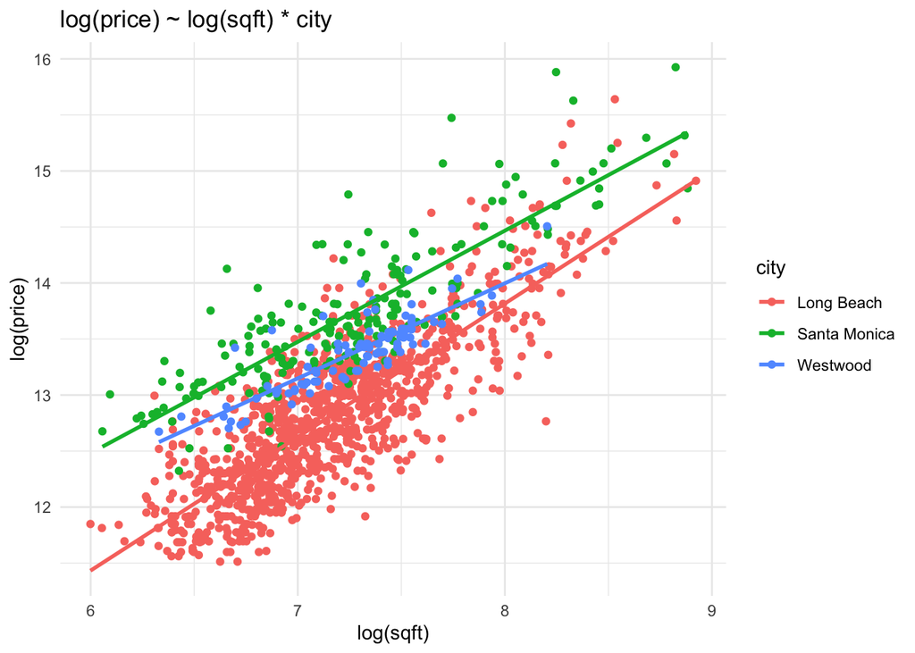

```r
# Plot of interaction

ggplot(d_noBH, aes(log(sqft), log(price), color=city)) +
  geom_point()+
  geom_smooth(method="lm", se=F)+
  theme_minimal() +
  ggtitle("log(price) ~ log(sqft) * city")
```

> *Answer*  
> The least square lines have slightly different slopes and have |t| values over 2 in the lm() model. This indicates city does have a significant interaction with log(sqft) (a>.01). It appears homes in Westwood appreciate at the lowest rate (smallest slope) as sqft increases while additional square footage in Long Beach will raise estimated house price at the fastest rate (largest slope). This is indicated in the model summary as well, with both Santa Monica’s and Westwood’s square foot interaction dummy variables having negative coefficients in reference to Long Beach’s.